# Presentación de Resultados

Juan De Leon, Maria Jose Castro, Jose Block

23/5/2021

### -Introducción

- Nacimientos por departamento según edad de la madre.
- Nacimientos por estado civil según edad de la madre.
- Nacimientos por edad de la madre según sexo y peso de bebé.

### -Conjuntos de entrenamiento y prueba:

Para los conjuntos de entrenamiento, se escogieron las porciones de 80% entrenamiento a 20%. Estas medidas las obtuvimos de unos apuntes de un curso de machine learning extraido de: https://developers.google.com/machine-learning/crash-course/training-and-test-sets/splitting-data. El primer algoritmo que se va a utilizar es un arbol de clasificación para determinar una jerarquía de importancia entre los datos. Seguido de Redes Neuronales para comprobar que tanto se puede predecir con los datos que se tienen, o sea a que porcentaje de precisión se puede llegar.

## - Arboles de Clasificación

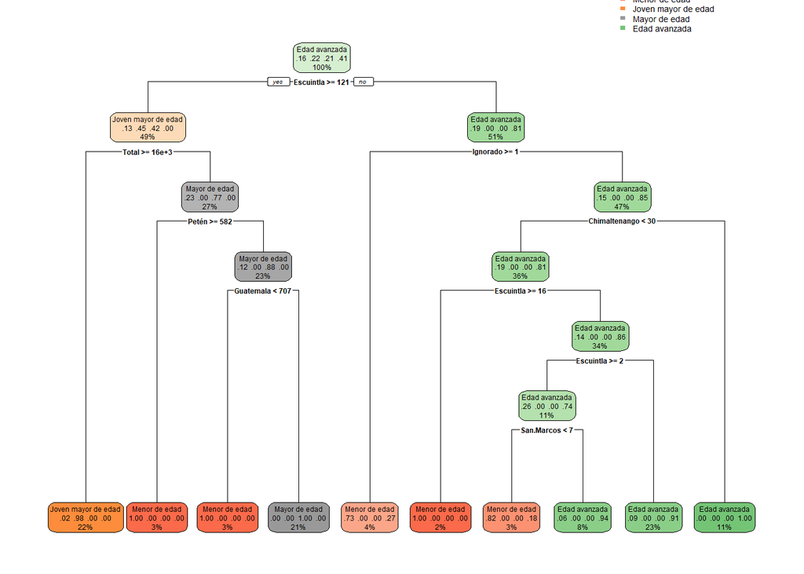

```
## Confusion Matrix and Statistics
##
##                      Reference
## Prediction            Menor de edad Joven mayor de edad Mayor de edad
##   Menor de edad                   8                   0             0
##   Joven mayor de edad             1                  22             0
##   Mayor de edad                   2                   1            18
##   Edad avanzada                   3                   0             0
##                      Reference
## Prediction            Edad avanzada
##   Menor de edad                   4
##   Joven mayor de edad             0
##   Mayor de edad                   0
##   Edad avanzada                  41
##
## Overall Statistics
##
##                Accuracy : 0.89
##                  95% CI : (0.8117, 0.9438)
##     No Information Rate : 0.45
##     P-Value [Acc > NIR] : < 2.2e-16
##
##                   Kappa : 0.8416
##
##  Mcnemar's Test P-Value : NA
##
## Statistics by Class:
##
##                      Class: Menor de edad Class: Joven mayor de edad
## Sensitivity                        0.5714                     0.9565
## Specificity                        0.9535                     0.9870
## Pos Pred Value                     0.6667                     0.9565
## Neg Pred Value                     0.9318                     0.9870
## Prevalence                         0.1400                     0.2300
## Detection Rate                     0.0800                     0.2200
## Detection Prevalence               0.1200                     0.2300
## Balanced Accuracy                  0.7625                     0.9718
##                      Class: Mayor de edad Class: Edad avanzada
## Sensitivity                        1.0000               0.9111
## Specificity                        0.9634               0.9455
## Pos Pred Value                     0.8571               0.9318
## Neg Pred Value                     1.0000               0.9286
## Prevalence                         0.1800               0.4500
## Detection Rate                     0.1800               0.4100
## Detection Prevalence               0.2100               0.4400
## Balanced Accuracy                  0.9817               0.9283
```

- Nacimientos por departamento según edad de la madre.

En el primer arbol de decisión se logró una accuracy aproximadamente de 89%, la cual está bastante bien. Que tenga una alta accuracy, asegura que los datos que se extraigan de este modelo van a ser bastante certeros. En el gráfico del árbol podemos notar que la suma de las casillas con título “Menor de edad” dan un resultado aproximado de un 15% de mujeres menores de edad(18) que están teniendo un hijo. Otro dato relevante es que le siguen las mujeres de 18 a 28 años siendo el 22%. Las variables relevantes de departamentos que determinan al modelo son las siguientes: Escuintla, Chimaltenango, Petén, Guatemala y San Marcos.

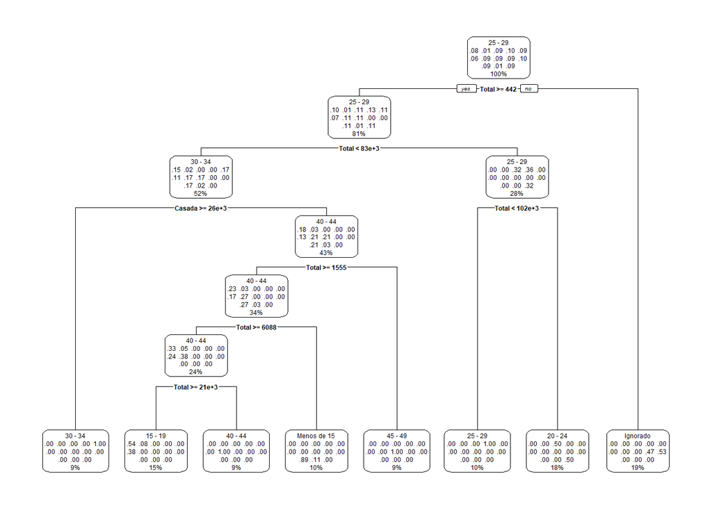

```
## Confusion Matrix and Statistics
##
##                   Reference
## Prediction         15 - 19 20 - 24 25 - 29 30 - 34 35 - 39 40 - 44 45 - 49
##   15 - 19                2       0       0       0       5       0       0
##   20 - 24                0       2       0       0       0       0       0
##   25 - 29                0       0       1       0       0       0       0
##   30 - 34                0       0       0       2       0       0       0
##   35 - 39                0       0       0       0       0       0       0
##   40 - 44                0       0       0       0       0       2       0
##   45 - 49                0       0       0       0       0       0       2
##   50 y más               0       0       0       0       0       0       0
##   Ignorado               0       0       0       0       0       0       0
##   Menos de 15            0       0       0       0       0       0       0
##   Todas las edades       0       0       0       0       0       0       0
##                   Reference
## Prediction         50 y más Ignorado Menos de 15 Todas las edades
##   15 - 19                 0        0           0                0
##   20 - 24                 0        0           0                2
##   25 - 29                 0        0           0                0
##   30 - 34                 0        0           0                0
##   35 - 39                 0        0           0                0
##   40 - 44                 0        0           0                0
##   45 - 49                 0        0           0                0
##   50 y más                0        0           0                0
##   Ignorado                2        1           0                0
##   Menos de 15             0        0           1                0
##   Todas las edades        0        0           0                0
##
## Overall Statistics
##
##                Accuracy : 0.5909
##                  95% CI : (0.3635, 0.7929)
##     No Information Rate : 0.2273
##     P-Value [Acc > NIR] : 0.0002579
##
##                   Kappa : 0.5551
##
##  Mcnemar's Test P-Value : NA
##
```

[output cut: 23 more lines]

```
## Pos Pred Value              1.00000             NaN         0.33333
## Neg Pred Value              1.00000         0.90909         1.00000
## Prevalence                  0.09091         0.09091         0.04545
## Detection Rate              0.09091         0.00000         0.04545
## Detection Prevalence        0.09091         0.00000         0.13636
## Balanced Accuracy           1.00000         0.50000         0.95238
##                      Class: Menos de 15 Class: Todas las edades
## Sensitivity                     1.00000                 0.00000
## Specificity                     1.00000                 1.00000
## Pos Pred Value                  1.00000                     NaN
## Neg Pred Value                  1.00000                 0.90909
## Prevalence                      0.04545                 0.09091
## Detection Rate                  0.04545                 0.00000
## Detection Prevalence            0.04545                 0.00000
## Balanced Accuracy               1.00000                 0.50000
```

- Nacimientos por estado civil según edad de la madre.

En este arbol se tiene una accuracy aproximadamente de 60%, es relativamente baja, pero igualment se decidió contemplar los datos de este. Cuenta con un 10% con menos de 15 años, y 15% de 15 a 19 años. Por ultimo de 20 a 24 años, es el 18% siendo un total del 43% de las madres del país tienen menos de 25 años.

[figure not shown]

```
## Confusion Matrix and Statistics
##
##                   Reference
## Prediction         15 - 19 20 - 24 25 - 29 30 - 34 35 - 39 40 - 44 45 - 49
##   15 - 19               19      12      20      14      12       8       0
##   20 - 24                3       3       5       6       0       0       0
##   25 - 29                0       5       2       4       0       0       0
##   30 - 34               16      10      16      13      10       4       0
##   35 - 39                3       0       0       0       9       0       0
##   40 - 44                1       3       5       4       7      29       3
##   45 - 49                0       0       0       0       0       0      18
##   50 y más               1       0       1       2       2       1      11
##   Ignorado               0       0       0       0       0       0       0
##   Menos de 15            0       0       0       0       0       2      10
##   Todas las edades       1       8       3       3       2       0       0
##                   Reference
## Prediction         50 y más Ignorado Menos de 15 Todas las edades
##   15 - 19                 0        1           0                5
##   20 - 24                 0        0           0                0
##   25 - 29                 0        0           0                1
##   30 - 34                 0        0           1                0
##   35 - 39                 0        0           0                0
##   40 - 44                 0        1          12                1
##   45 - 49                 8        6          13                0
##   50 y más               27       17           8                0
##   Ignorado               11       14           0                0
##   Menos de 15             1        1          12                0
##   Todas las edades        0        0           0               33
##
## Overall Statistics
##
##                Accuracy : 0.3698
##                  95% CI : (0.3267, 0.4146)
##     No Information Rate : 0.1074
##     P-Value [Acc > NIR] : < 2.2e-16
##
##                   Kappa : 0.3067
##
##  Mcnemar's Test P-Value : NA
##
```

[output cut: 23 more lines]

```
## Pos Pred Value              0.40000         0.38571         0.56000
## Neg Pred Value              0.94533         0.95169         0.94336
## Prevalence                  0.08678         0.09711         0.08264
## Detection Rate              0.03719         0.05579         0.02893
## Detection Prevalence        0.09298         0.14463         0.05165
## Balanced Accuracy           0.68374         0.73803         0.66261
##                      Class: Menos de 15 Class: Todas las edades
## Sensitivity                     0.26087                 0.82500
## Specificity                     0.96804                 0.96171
## Pos Pred Value                  0.46154                 0.66000
## Neg Pred Value                  0.92576                 0.98387
## Prevalence                      0.09504                 0.08264
## Detection Rate                  0.02479                 0.06818
## Detection Prevalence            0.05372                 0.10331
## Balanced Accuracy               0.61445                 0.89336
```

- Nacimientos por edad de la madre según sexo y peso de bebé.

En este modelo se consiguió una accuracy de aproximadamente 37%, por lo que no se tomarán en cuenta los datos de este modelo. Se puede concluir tambien que la variable edad no define el sexo ni el peso del bebé, debido a su poca relación.

## - Redes Neuronales

```
## Confusion Matrix and Statistics
##
##
##      1  2  3  4
##   1  8  0  0  0
##   2  0 22  0  0
##   3  0  0 26  0
##   4  6  0  1 37
##
## Overall Statistics
##
##                Accuracy : 0.93
##                  95% CI : (0.8611, 0.9714)
##     No Information Rate : 0.37
##     P-Value [Acc > NIR] : < 2.2e-16
##
##                   Kappa : 0.901
##
##  Mcnemar's Test P-Value : NA
##
## Statistics by Class:
##
##                      Class: 1 Class: 2 Class: 3 Class: 4
## Sensitivity            0.5714     1.00   0.9630   1.0000
## Specificity            1.0000     1.00   1.0000   0.8889
## Pos Pred Value         1.0000     1.00   1.0000   0.8409
## Neg Pred Value         0.9348     1.00   0.9865   1.0000
## Prevalence             0.1400     0.22   0.2700   0.3700
## Detection Rate         0.0800     0.22   0.2600   0.3700
## Detection Prevalence   0.0800     0.22   0.2600   0.4400
## Balanced Accuracy      0.7857     1.00   0.9815   0.9444
```

- Nacimientos por departamento según edad de la madre.

Con la accuracy aproximada de 93% del modelo se puede comprobar aún más la ceracidad de la información recolectada del arbol de clasificación. Concuerda en que La variable edad tiene mucho que ver entre departamentos, por lo que sí debería de ser parte de nuestra categorización de departamentos en los cuales invertir en educación.

```
## Confusion Matrix and Statistics
##
##
##                    15 - 19 Todas las edades Ignorado 35 - 39 45 - 49 20 - 24
##   15 - 19                1                0        0       0       0       0
##   Todas las edades       0                1        0       0       0       0
##   Ignorado               0                0        2       0       0       0
##   35 - 39                0                0        0       3       0       0
##   45 - 49                0                0        0       0       6       0
##   20 - 24                0                0        0       0       0       3
##   50 y más               0                0        0       0       0       0
##   30 - 34                0                0        0       0       0       0
##   40 - 44                0                0        0       0       0       0
##   Menos de 15            0                0        0       0       0       0
##   25 - 29                0                0        0       0       0       0
##   Menos de 18            0                0        0       0       0       0
##   18 - 19                0                0        0       0       0       0
##
##                    50 y más 30 - 34 40 - 44 Menos de 15 25 - 29 Menos de 18
##   15 - 19                 0       0       0           0       0           0
##   Todas las edades        0       0       0           0       1           0
##   Ignorado                0       0       0           0       0           0
##   35 - 39                 0       0       0           0       0           0
##   45 - 49                 0       0       0           0       0           0
##   20 - 24                 0       0       0           0       0           0
##   50 y más                1       0       0           0       0           0
##   30 - 34                 0       1       0           0       0           0
##   40 - 44                 0       0       1           0       0           0
##   Menos de 15             0       0       0           0       0           1
##   25 - 29                 0       0       0           0       0           0
##   Menos de 18             0       0       0           0       0           0
##   18 - 19                 0       0       0           0       0           0
##
##                    18 - 19
##   15 - 19                1
##   Todas las edades       0
##   Ignorado               0
##   35 - 39                0
##   45 - 49                0
##   20 - 24                0
```

[output cut: 51 more lines]

```
## Pos Pred Value                       NA            NaN                NaN
## Neg Pred Value                       NA        0.95455            0.95455
## Prevalence                      0.00000        0.04545            0.04545
## Detection Rate                  0.00000        0.00000            0.00000
## Detection Prevalence            0.04545        0.00000            0.00000
## Balanced Accuracy                    NA        0.50000            0.50000
##                      Class: 18 - 19
## Sensitivity                 0.00000
## Specificity                 1.00000
## Pos Pred Value                  NaN
## Neg Pred Value              0.95455
## Prevalence                  0.04545
## Detection Rate              0.00000
## Detection Prevalence        0.00000
## Balanced Accuracy           0.50000
```

- Nacimientos por estado civil según edad de la madre.

Este modelo con una accuracy aproximada a 86% respalda la información extraida del árbol de clasificación de esta tabla, ya que muestra que si hay mucha relación entre el estado civil de la madre y su edad. Por lo tanto, la edad juega un rol importante en una madre sin pareja, lo cual sí afecta al acceso de educación a estos casos.

```
## Confusion Matrix and Statistics
##
##
##                    30 - 34 15 - 19 Todas las edades 45 - 49 Ignorado 35 - 39
##   30 - 34               27      16                4       3        7      10
##   15 - 19                5       8                1       0        0       0
##   Todas las edades       0       1               40       0        0       0
##   45 - 49                0       1                0      11       14       4
##   Ignorado               0       0                0      11       13       0
##   35 - 39                9       4                0       1        2      17
##   25 - 29                6       5                0       0        0       0
##   20 - 24                3       1                1       0        0       0
##   40 - 44                0       0                0       5        8       1
##   Menos de 15            0       0                0       4        8       0
##   50 y más               0       0                0       0        0       0
##
##                    25 - 29 20 - 24 40 - 44 Menos de 15 50 y más
##   30 - 34               20      17       5           4        7
##   15 - 19                2       0       0           0        0
##   Todas las edades       4       6       0           0        0
##   45 - 49                0       0      12          16       20
##   Ignorado               0       0       0          17        8
##   35 - 39                3       0       2           2        1
##   25 - 29                7       4       0           0        0
##   20 - 24               13      15       0           0        0
##   40 - 44                0       0      23           6        4
##   Menos de 15            0       0       1           3       11
##   50 y más               0       0       0           0        0
##
## Overall Statistics
##
##                Accuracy : 0.3388
##                  95% CI : (0.2967, 0.3829)
##     No Information Rate : 0.1074
##     P-Value [Acc > NIR] : < 2.2e-16
##
##                   Kappa : 0.2727
##
##  Mcnemar's Test P-Value : NA
##
```

[output cut: 23 more lines]

```
## Pos Pred Value              0.31818        0.45455        0.48936
## Neg Pred Value              0.90909        0.94013        0.95423
## Prevalence                  0.10124        0.08678        0.08884
## Detection Rate              0.01446        0.03099        0.04752
## Detection Prevalence        0.04545        0.06818        0.09711
## Balanced Accuracy           0.55419        0.65821        0.74023
##                      Class: Menos de 15 Class: 50 y más
## Sensitivity                    0.062500          0.0000
## Specificity                    0.944954          1.0000
## Pos Pred Value                 0.111111             NaN
## Neg Pred Value                 0.901532          0.8946
## Prevalence                     0.099174          0.1054
## Detection Rate                 0.006198          0.0000
## Detection Prevalence           0.055785          0.0000
## Balanced Accuracy              0.503727          0.5000
```

- Nacimientos por edad de la madre según sexo y peso de bebé.